# K-means Clustering on MNIST

## Imports

```python
from mlxtend.data import loadlocal_mnist
import platform
import numpy as np
from scipy.spatial import distance
import matplotlib.pyplot as plt
import pandas as pd
```

**Note:** mlxtend can be installed by executing `pip install mlxtend`

## Setup

These will be the global variables that I used throughout this project. Since **`k_means`** is an unsupervised learning algorithm, `X` will be used to perform the actual clustering. The label set, `y`, will be used only for determining the classification accuracy.

```python
# Loading MNIST into NumPy Arrays
if not platform.system() == 'Windows':
    X, y = loadlocal_mnist(
            images_path='train-images-idx3-ubyte',
            labels_path='train-labels-idx1-ubyte')
else:
    X, y = loadlocal_mnist(
            images_path='train-images-idx3-ubyte',
            labels_path='train-labels-idx1-ubyte')
```

## Normalization of Training Set

This step was purely optional as my **`k_means`** algorithm worked fine without it. However, for the sake of achieving similar *J<sub>clust</sub>* values as the ones shown in the textbook, I ultimately decided to normalize the training set, `X`. The formula I used for the normalization was:

X<sub>new</sub> = (X - X<sub>min</sub>)/X<sub>max</sub> - X<sub>min</sub>

Thus, the vectors will be rescaled to have values between 0 and 1.

```python
def min_max_normalize(train):
    """
    Normalizes the training set by rescaling the vectors
    to have values between 0 and 1
    """
    train = train.astype(float)
    for image in train:
        _max = np.max(image)
        _min = np.min(image)
        if _max == 0 and _min == 0:
            continue
        image -= _min
        image /= (_max -_min)
    return train
```

```python
# RUN THIS CELL TO NORMALIZE TRAINING SET
X = min_max_normalize(X)
```

## Initialization

The initialization technique I used for my **`k_means`** method is randomly sampling *k* vectors from our training set, `X`, to be the initial *k* group representatives (centroids).

```python
def rand_centroids(k):
    """
    Returns initial group representatives by randomly sampling
    k vectors from the training set
    """
    return X[np.random.choice(X.shape[0], k, replace=False)]
```

## Termination

I defined the convergence of my algorithm as when the percent decrease of the clustering objective, *J<sub>clust</sub>* , falls under an arbitrary threshold, which I defined to be as **0.05%**.

Frankly, this decision was a hard one. I wanted to achieve optimal clustering for every run, so I initially defined the threshold to be 0.01%. However, this took an upwards of 20 minutes for one run and 30 runs seemed unthinkable. Ultimately, I decided to use 0.05% as the threshold as it seemed to plot nice *J<sub>clust</sub>* graphs, akin to the ones in the textbook, and wasn't too crazy with the runtime.

The following methods implement this functionality.

```python
def percent_decrease(new_jclust, old_jclust):
    """
    Calculates the percent decrease of an iteration's J_clust compared
    to the previous value of J_clust
    """
    return np.abs(100*(new_jclust - old_jclust)/old_jclust)
```

```python
def conv_condition(decrease):
    """
    Helper function for the convergence condition, which is when the
    percent decrease of J_clust is < 0.1%
    """
    if decrease <= .05:
        return False
    return True
```

## The K-means Algorithm

The following are helper functions I wrote that are used in implementing the **`k_means`** function. These including calculating the euclidean distance and mean of vectors, as well as partitioning the vectors into *k* clusters (groups) and updating the group representatives.

```python
def sum_vectors(vector_list):
    """
    Returns the sum of a list of vectors
    """
    _sum = np.zeros(X.shape[1])
    for vector in vector_list:
        _sum += vector
    return _sum
```

```python
def mean_vectors(vector_list):
    """
    Returns the mean of a list of vectors
    """
    _mean = sum_vectors(vector_list)*1.0/len(vector_list)
    return _mean
```

```python
def euclidean_distance(X_1, X_2):
    """
    Calculates the Euclidean distance between 2 multidimensional
    vectors
    """
    return distance.euclidean(X_1, X_2)
```

```python
def j_clust(group_labels, centroids):
    """
    Calculates the clustering objective, J_clust
    """
    # Initialize empty list to hold distances
    distances = []
    for i, label in enumerate(group_labels):
        # Calculate Euclidean distance from each image and its
        # group representatives
        distance = euclidean_distance(X[i], centroids[label - 1])
        distances.append(distance)
    sq_sum = 0
    for distance in distances:
        # Calculate sum of squares of distances
        sq_sum+=distance**2
    # Return the mean sum of squares of distances
    return sq_sum/len(group_labels)
```

```python
def form_clusters(centroids):
    """
    Partitions the vectors into k clusters(groups) and
    outputs each vector's cluster label
    """
    # Initialize empty list to hold the group labels of every
    # vector in the training set
    group_labels = []
    # Iterate through images in training set
    for i in range(len(X)):
        distances = []
        # Calculate distance from image and each centroid
        for centroid in centroids:
            distance = euclidean_distance(X[i], centroid)
            distances.append(distance)
        # Assign image to its nearest centroid
        index = distances.index(min(distances))
        group_labels.append(index + 1)
    return group_labels
```

```python
def update_centroids(group_labels, k):
    """
    Updates the group representatives, by assuming the memberships of the
    clusters are correct
    """
    # Initialize empty list to hold the k centroids
    centroids = [[] for i in range(k)]
    # For each group index, append the associated vector of
    # the training set
    for i, label in enumerate(group_labels):
        centroids[label - 1].append(X[i])
    # Calculate the mean of the vectors associated with each
    # group index
    for j, vector_list in enumerate(centroids):
        centroids[j] = mean_vectors(vector_list)
    return centroids
```

The following is the **`k_means`** function that takes in the normalized training set, `X`, and *k* number of clusters. The function outputs a tuple consisting of three quantities: `group_labels`, the list of the 60000 group indices corresponding to each image in the training set, `centroids`, the list of the group representative vectors, `j_clusts`, the list of the *J<sub>clust</sub>* values for every iteration until convergence

```python
def k_means(X, k):
    """
    Performs the k-means algorithm on the training set, X, using
    k clusters
    """
    # Randomly initialize k centroids
    centroids = rand_centroids(k)
    # Initialze empty list to hold J_clust values from each iteration
    j_clusts = []
    # Initialize the old and new J_clusts as infinity
    old_jclust = new_jclust = decrease = float('inf')
    i = 0

    # Iterate until percent decrease of J_clust is <= 0.1%
    while (conv_condition(decrease)):
        # Decide the cluster memberships of the vectors
        group_labels = form_clusters(centroids)
        # Re-estimate the k centroids under the new clusters
        centroids = update_centroids(group_labels, k)
        # Calculate the clustering objective
        new_jclust = j_clust(group_labels, centroids)
        j_clusts.append(new_jclust)
        # Calculate the percent decrease of J_clust
        decrease = percent_decrease(new_jclust, old_jclust)
        print("Percent decrease for loop {} is {}%".format(i + 1, round(decrease, 2)))
        old_jclust = new_jclust
        i+=1
    return group_labels, centroids, j_clusts
```

## K-means Using 20 clusters

Here, I performed the **`k-means`** algorithm on the training set, *X*, using *k* = 20 clusters. In accordance with the instructions, I repeated this experiment *P* = 30 times. I implemented the function **`repeat_kmeans`** which allows me to run **`k_means`** for *P* runs. The function outputs the two runs with the lowest and highest value of *J<sub>clust</sub>* upon convergence.

```python
def min_and_max(j_clusts):
    """
    Helper function to return the two runs with the highest J_clust and
    lowest J_clust
    """
    return np.argmin(j_clusts), np.argmax(j_clusts)
```

```python
def repeat_kmeans(X, k, P):
    """
    Returns the two runs of k_means with the lowest and highest J_clust
    upon convergence
    """
    # Initialize empty lists to hold the return values of k_means of every
    # run
    group_labels_list = []
    centroids_list = []
    j_clusts_list = []
    # Initialize empty lists to hold the return values of k_means of the run
    # with the lowest and highest J_clust values upon convergence
    min_run = []
    max_run = []

    # Iterate for P runs
    for i in range(P):
        print("Entering Run {}...".format(i + 1))
        # Run k_means
        group_labels, centroids, j_clusts = k_means(X, k)
        group_labels_list.append(group_labels)
        centroids_list.append(centroids)
        j_clusts_list.append(j_clusts)
        print("Finished Run {}!".format(i + 1))

    # Initialize empty list to hold the final J_clust values for every run
    conv_values = []
    for j_clusts in j_clusts_list:
        # For every run, get final J_clust value
        conv_val = j_clusts[len(j_clusts) - 1]
        conv_values.append(conv_val)

    # Get index of run with lowest and highest final J_clust value
    min_jclust_ind, max_jclust_ind = min_and_max(conv_values)

    # Append the return values of both runs to empty lists
    min_run.append(group_labels_list[min_jclust_ind])
    min_run.append(centroids_list[min_jclust_ind])
    min_run.append(j_clusts_list[min_jclust_ind])

    max_run.append(group_labels_list[max_jclust_ind])
    max_run.append(centroids_list[max_jclust_ind])
    max_run.append(j_clusts_list[max_jclust_ind])

    return min_run, max_run
```

```python
# RUN THIS CELL TO PERFORM K-MEANS ON 20 CLUSTERS, 30 TIMES
min_run_twenty, max_run_twenty = repeat_kmeans(X, 20, 30)
```

```
Entering Run 1...
Percent decrease for loop 1 is nan%
Percent decrease for loop 2 is 6.97%
Percent decrease for loop 3 is 3.07%
Percent decrease for loop 4 is 1.31%
Percent decrease for loop 5 is 0.55%
Percent decrease for loop 6 is 0.33%
Percent decrease for loop 7 is 0.24%
Percent decrease for loop 8 is 0.18%
Percent decrease for loop 9 is 0.12%
Percent decrease for loop 10 is 0.09%
Percent decrease for loop 11 is 0.06%
Percent decrease for loop 12 is 0.04%
Finished Run 1!
Entering Run 2...
Percent decrease for loop 1 is nan%
Percent decrease for loop 2 is 6.98%
Percent decrease for loop 3 is 2.28%
Percent decrease for loop 4 is 1.32%
Percent decrease for loop 5 is 0.8%
Percent decrease for loop 6 is 0.46%
Percent decrease for loop 7 is 0.26%
Percent decrease for loop 8 is 0.15%
Percent decrease for loop 9 is 0.09%
Percent decrease for loop 10 is 0.06%
Percent decrease for loop 11 is 0.04%
Finished Run 2!
Entering Run 3...
Percent decrease for loop 1 is nan%
Percent decrease for loop 2 is 5.96%
Percent decrease for loop 3 is 1.31%
Percent decrease for loop 4 is 0.5%
Percent decrease for loop 5 is 0.31%
Percent decrease for loop 6 is 0.23%
Percent decrease for loop 7 is 0.22%
Percent decrease for loop 8 is 0.21%
Percent decrease for loop 9 is 0.19%
Percent decrease for loop 10 is 0.14%
Percent decrease for loop 11 is 0.09%
Percent decrease for loop 12 is 0.06%
```

[output cut: 437 more lines]

```
Percent decrease for loop 4 is 1.11%
Percent decrease for loop 5 is 0.59%
Percent decrease for loop 6 is 0.35%
Percent decrease for loop 7 is 0.24%
Percent decrease for loop 8 is 0.21%
Percent decrease for loop 9 is 0.2%
Percent decrease for loop 10 is 0.18%
Percent decrease for loop 11 is 0.16%
Percent decrease for loop 12 is 0.13%
Percent decrease for loop 13 is 0.1%
Percent decrease for loop 14 is 0.07%
Percent decrease for loop 15 is 0.07%
Percent decrease for loop 16 is 0.06%
Percent decrease for loop 17 is 0.05%
Finished Run 30!
```

The above call to **`repeat_kmeans`** returns the runs for **`k_means`** using 20 clusters which produced the lowest *J<sub>clust</sub>* value upon convergence and highest *J<sub>clust</sub>* upon convergence value. These runs are stored in `min_run_twenty` and `max_run_twenty` respectively, and I will be referencing these variables in the next portion of the write-up.

### Visualization of *J<sub>clust</sub>*

**`viz_jclust`** takes in a run which produced the minimum final value of *J<sub>clust</sub>* and run that produced the maximum, and plots *J<sub>clust</sub>* values as a function of iterations for both runs.

```python
def viz_jclust(min_run, max_run):
    """
    Visualizes J_clust as a function of iterations for both runs
    """
    min_jclust = min_run[2]
    max_jclust = max_run[2]
    plt.figure(figsize = (12, 6))
    plt.suptitle('Lowest and Highest Convergence Value of J_clust', fontsize = 15)
    # Plot subplot for lowest convergence value
    plt.subplot(1, 2, 1)
    y_min = min_jclust
    x_min = [x + 1 for x in range(len(y_min))]
    plt.plot(x_min, y_min)
    plt.xlabel('Iteration')
    plt.ylabel('J_clust')
    plt.title('Lowest Convergence Value')
    # Plot sublot for highest convergence value
    plt.subplot(1, 2, 2)
    y_max = max_jclust
    x_max = [x + 1 for x in range(len(y_max))]
    plt.plot(x_max, y_max)
    plt.xlabel('Iteration')
    plt.ylabel('J_clust')
    plt.title('Highest Convergence Value')
```

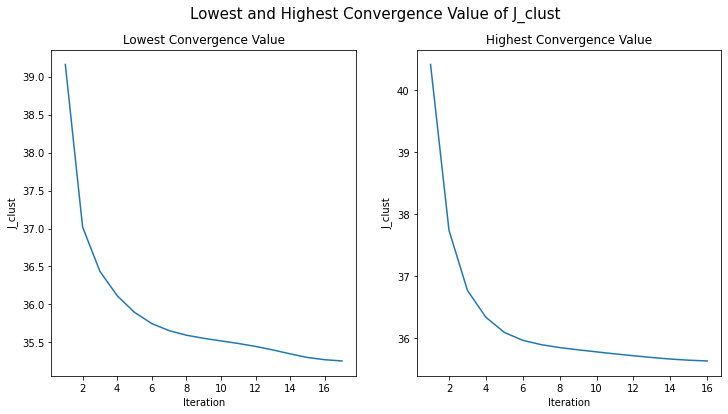

```python
# RUN THIS CELL TO VISUALIZE J_CLUST CONVERGENCE VALUES FOR BOTH RUNS
viz_jclust(min_run_twenty, max_run_twenty)
```

```python
# RUN THIS CELL TO PRINT THE MAXIMUM AND MINIMUM J_CLUST CONVERGENCE VALUES
lowest_jclust_twenty = min_run_twenty[2][len(min_run_twenty[2]) - 1]
highest_jclust_twenty = max_run_twenty[2][len(max_run_twenty[2]) - 1]
print('The lowest convergence value of J_clust was {}'.format(round(lowest_jclust_twenty, 2)))
print('The highest convergence value of J_clust was {}'.format(round(highest_jclust_twenty, 2)))
```

```
The lowest convergence value of J_clust was 35.26
The highest convergence value of J_clust was 35.64
```

The above line graphs depict *J<sub>clust</sub>* versus iteration number for two of the initial 20 random assignment of group representatives that gave the lowest and highest final values of *J<sub>clust</sub>* upon convergence. As printed above, the lowest convergence value of the objective was around 35.26 and the highest convergence value of the objective was around 35.64. It doesn't seem to be much of a difference, but considering we're taking the MSE of the distances of 60,000 vectors to its group representatives, the 0.4 difference could differentiate between a strong clustering and a good one.

Aside from the fact that `min_run_twenty` took 17 iterations to reach convergence and `max_run_twenty` took 16 (not much of a difference), the line graphs display similar behavior. These final *J<sub>clust</sub>* values could've been lower, albeit not significantly, had I chosen a more extreme convergence condition. However, considering the convergence condition I have right now takes about 2 hours to conduct the 30 experiments, I am content with my choice of convergence condtition.

### Visualizing the Group Representatives as Images

The function **`display_images`** takes in both runs as inputs and displays the group representatives produced by each run as 28x28 grayscale images.

```python
def display_images(min_run, max_run):
    """
    Displays the two sets of centroids produced by each run as 28*28 grayscale images
    """
    min_centroids = min_run[1]
    max_centroids = max_run[1]
    k = len(min_centroids)
    grid_length = 5
    grid_height = k/grid_length

    # Initialize size of plot as function of k
    plt.figure(figsize = (grid_length, grid_height + 1))
    plt.suptitle('Lowest Jclust Convergence Value', fontsize = 14)
    for i, centroid in enumerate(min_centroids):
        # Reshape the vector as a 28*28 vector
        img = centroid.reshape(28, 28)
        # Plot the image as a subplot with grayscale
        plt.subplot(grid_height, grid_length, i + 1).axis('off')
        plt.imshow(img, cmap = 'gray')

    # Repeat above for max run
    plt.figure(figsize = (grid_length, grid_height + 1))
    plt.suptitle('Highest Jclust Convergence Value', fontsize = 14)
    for i, centroid in enumerate(max_centroids):
        img = centroid.reshape(28, 28)
        plt.subplot(grid_height, grid_length, i + 1).axis('off')
        plt.imshow(img, cmap = 'gray')
```

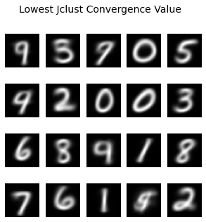

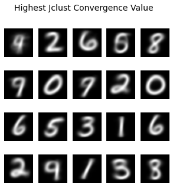

```python
# RUN THIS CELL TO DISPLAY THE K CENTROIDS AS IMAGES FOR BOTH RUNS
display_images(min_run_twenty, max_run_twenty)
```

The above images shows the set of group representatives with the lowest final value of the clustering objective from `min_run_twenty`, and the set of representatives with the highest final value from `max_run_twenty`. Almost all of the representatives are recognizable digits. The only exceptions seem to arise from the ambiguity between *9* and *4*, *3* and *8*, or *3* and *5*, which isn't unexpected given their similarities.

For the set of group representatives from `min_run_twenty`, I can see about 5 digits where it is hard to classify by the eye-test. Most of the digits are where I think it is *9* but it could be a *7* or *4*. The digit *5* is blurry enough where it could also be interpreted as a *3*. In the set of representatives from `max_run_twenty`, I can see about six digits where it was hard to pinpoint exactly what digit the group represents. In this set, *3* is hard to distinguish from an *8* and *9* could be a *7* or *4*.

### The 10 Nearest Images for Each Centroid

I defined **`ten_nearest`** to find the ten nearest images for each group representative, whilst also returning the *actual* digits that these vectors are supposed to represent by using `y`, the set of training labels. This way, I can use these values in determining the classification accuracy of the set of ten nearest vectors for each group.

```python
def ten_nearest(min_run, max_run):
    """
    For both runs, returns the 10 nearest vectors to each centroid, and also
    returns the actual digits these vectors are supposed to represent
    """
    min_group_labels = min_run[0]
    min_centroids = min_run[1]
    max_group_labels = max_run[0]
    max_centroids = max_run[1]

    # Initialize empty list to hold the 10 nearest vectors for each centroid
    min_nearest = [[] for i in range(len(min_centroids))]
    # Initialize empty list to hold the actual labels for the 10 nearest
    # vectors for each centroid
    min_digits = [[] for i in range(len(min_centroids))]

    # Iterate through centroids
    for i in range(len(min_centroids)):
        distances = []
        indices = []
        # Calculate distance from centroid to every vector in its cluster
        for j, label in enumerate(min_group_labels):
            if label == i + 1:
                distance = euclidean_distance(X[j], min_centroids[i])
                distances.append(distance)
                indices.append(j)
        # Get index of ten smallest distances
        ten_smallest = np.argpartition(distances, 10)[:10]
        # Use indices to retrieve the associated vector and its label
        for k in ten_smallest:
            min_nearest[i].append(X[indices[k]])
            min_digits[i].append(y[indices[k]])

    # Repeat for max run
    max_nearest = [[] for i in range(len(max_centroids))]
    max_digits = [[] for i in range(len(max_centroids))]
    for i in range(len(max_centroids)):
        distances = []
        indices = []
        for j, label in enumerate(max_group_labels):
            if label == i + 1:
                distance = euclidean_distance(X[j], max_centroids[i])
                distances.append(distance)
                indices.append(j)
        ten_smallest = np.argpartition(distances, 10)[:10]
        for k in ten_smallest:
            max_nearest[i].append(X[indices[k]])
            max_digits[i].append(y[indices[k]])

    return min_nearest, min_digits, max_nearest, max_digits
```

```python
# RUN THIS CELL TO GET THE 10 CLOSEST VECTORS, AND THEIR ACTUAL LABEL, TO EACH CENTROID
min_nearest_twenty, min_actual_twenty, max_nearest_twenty, max_actual_twenty = ten_nearest(min_run_twenty, max_run_twenty)
```

By eye estimation, I manually deduced the digit that each group is supposed to represent. For `min_run_twenty`, the digits in order seem to be:

*9, 3, 9, 0, 5, 4, 2, 0, 0, 3, 6, 8, 9, 1, 8, 7, 6, 1, 5, 2*

Likewise, for `max_run_twenty`, the digits in order look like:

*4, 2, 6, 5, 8, 9, 0, 9, 2, 0, 6, 5, 3, 1, 6, 2, 9, 1, 3, 8*

I inputted these values into two lists.

```python
# RUN THIS CELL TO STORE THE EYE ESTIMATES OF THE DIGITS INTO LISTS
min_inferred_twenty = [9, 3, 9, 0, 5, 4, 2, 0, 0, 3, 6, 8, 9, 1, 8, 7, 6, 1, 5, 2]
max_inferred_twenty = [4, 2, 6, 5, 8, 9, 0, 9, 2, 0, 6, 5, 3, 1, 6, 2, 9, 1, 3, 8]
```

#### Tables

The below function **`create_table`** creates a table depicting the number of correctly classified vectors of the 10 nearest vectors for each group representative. As mentioned above, I am using the *actual* training labels of each of ten nearest vectors to determine the classification accuracy, by checking if they *match* the inferred digit of its group representative.

```python
def create_table(inferred_digits, actual_digits):
    """
    Creates a Pandas DataFrame displaying the number of correctly
    classified vectors of the 10 nearest vectors for each group
    representative
    """
    group_indices = []
    correct = []
    misclassified = []
    for i in range(len(inferred_digits)):
        group_indices.append(i + 1)
    for i, batch in enumerate(actual_digits):
        num_correct = 0
        for digit in batch:
            if inferred_digits[i] == digit:
                num_correct+=1
        correct.append(num_correct)
        misclassified.append(10 - num_correct)
    data = {'Group Index' : group_indices,
            'Inferred Digit' : inferred_digits,
            'Correctly Classified' : correct}
    table = pd.DataFrame(data)
    return table
```

The table below displays the number of correctly classified in the set of ten nearest vectors for `min_run_twenty`.

```python
# RUN THIS CELL TO GENERATE TABLE FOR THE RUN WITH THE LOWEST FINAL J_CLUST VALUE
create_table(min_inferred_twenty, min_actual_twenty)
```

|  | Group Index | Inferred Digit | Correctly Classified |
| --- | --- | --- | --- |
| 0 | 1 | 9 | 10 |
| 1 | 2 | 3 | 8 |
| 2 | 3 | 9 | 0 |
| 3 | 4 | 0 | 10 |
| 4 | 5 | 5 | 10 |
| 5 | 6 | 4 | 6 |
| 6 | 7 | 2 | 10 |
| 7 | 8 | 0 | 10 |
| 8 | 9 | 0 | 10 |
| 9 | 10 | 3 | 10 |
| 10 | 11 | 6 | 10 |
| 11 | 12 | 8 | 5 |
| 12 | 13 | 9 | 6 |
| 13 | 14 | 1 | 10 |
| 14 | 15 | 8 | 10 |
| 15 | 16 | 7 | 10 |
| 16 | 17 | 6 | 10 |
| 17 | 18 | 1 | 10 |
| 18 | 19 | 5 | 5 |
| 19 | 20 | 2 | 10 |

For the most part, this run produced decent classifications considering the algorithm knew nothing the label set, digits, or handwriting. However, for a couple of digits it produced severe misclassifications. Take group 3 for example, which had a stunning *zero* correct classifications. However, this isn't a knock on the clustering algorithm or my choice of the convergence condition. I had estimated that it's group representative looks like the digit *9*, when it also could've been interpreted as a *7*. It is *extremely* likely then, that the 10 nearest vectors for this group representative is actually a *7*, and the vectors with the label *9* are prevalent in the cluster, but just not part of the ten closest to the representative. This is probably also true for group 13, which had a mediocre 60% classification rate, as I again inferred its group representative to be *9*, but it also looks awfully close to the digit *4* as well.

Other misclassifications in the sets of the ten nearest vectors include groups 12 and 19 whose representatives I had inferred to be *8*,and *5*, respectively. Both of these groups had an unininspiring 50% classification rate. Group 6 whose group representative I had inferred to be *4* had a 60% classification rate. Thinking back to the Least Squares Classifiers, I am sure a couple of the nearest vectors in this group are actually the digit *9*, as these digits can sometimes be relatively close together in the 784-vector space.

The table below displays the number of correctly classified in the set of ten nearest vectors for `max_run_twenty`.

```python
# RUN THIS CELL TO GENERATE TABLE FOR THE RUN WITH THE HIGHEST FINAL J_CLUST VALUE
create_table(max_inferred_twenty, max_actual_twenty)
```

|  | Group Index | Inferred Digit | Correctly Classified |
| --- | --- | --- | --- |
| 0 | 1 | 4 | 6 |
| 1 | 2 | 2 | 10 |
| 2 | 3 | 6 | 10 |
| 3 | 4 | 5 | 9 |
| 4 | 5 | 8 | 10 |
| 5 | 6 | 9 | 3 |
| 6 | 7 | 0 | 10 |
| 7 | 8 | 9 | 0 |
| 8 | 9 | 2 | 10 |
| 9 | 10 | 0 | 10 |
| 10 | 11 | 6 | 10 |
| 11 | 12 | 5 | 10 |
| 12 | 13 | 3 | 10 |
| 13 | 14 | 1 | 10 |
| 14 | 15 | 6 | 10 |
| 15 | 16 | 2 | 10 |
| 16 | 17 | 9 | 5 |
| 17 | 18 | 1 | 10 |
| 18 | 19 | 3 | 10 |
| 19 | 20 | 8 | 1 |

Like the previous run, this run which produced the *highest* final *J<sub>clust</sub>* value, also decently classified the handwritten digits. Of the 20 clusters, the ten nearest vectors to the representatives of 14 clusters produced a 100% classification rate, identical to the run with the lowest final *J<sub>clust</sub>* value.

Also similar to the previous run, I had again inferred group representatives to be the digit *9* for groups 6, 8, and 17. And as expected, the ten nearest vectors for these respective groups were also miserably classified. These groups had a 30%, 0%, and 50% classification rate, respectively. And again, as I postulated above, this is likely due to my misinterpretation of what the group representatives of these groups look like. These images could've very well had represented *7* or *4*, as these are commonly misclassified with *9*.

Group 20 whose representative I had inferred to be *8*, had about a 10% classification rate in the set of the nearest vectors. This observation is similar to the previous run, where *8* also had a high misclassification rate in its set. Thinking back to the Least Squares Classifier, it is likely that *3*, which also seems to be in the general proximity of *8* in the 784-vector space, is prevalent as much as *8* in these clusters.

#### Visualizing Misclassified Data Points as Images

With the method below, we can plot a few of the correctly classified as well as misclassified data points as images, alongside the group representatives (also represented as images).

```python
def display_misclassified(run, nearest_vectors, inferred, actual):
    """
    Displays the correctly classified and misclassified data points of the 10 nearest vectors for each group
    representative
    """
    centroids = run[1]
    grid_length = 20
    grid_height = grid_length*1.85
    plt.figure(figsize = (grid_length, grid_height))

    offset = 0
    for i, vector in enumerate(actual):
        centroid_img = centroids[i].reshape(28, 28)
        plt.subplot(grid_length, 11,  offset + 1).axis('off')
        plt.imshow(centroid_img, cmap = 'gray')
        plt.title('Centroid', fontsize = 12)
        for j, digit in enumerate(vector):
            if inferred[i] == digit:
                correct_img = nearest_vectors[i][j].reshape(28, 28)
                plt.subplot(grid_length, 11, j + 2 + offset).axis('off')
                plt.imshow(correct_img, cmap = 'gray')
                plt.title('Classified', fontsize = 12)
            else:
                misclassified_img = nearest_vectors[i][j].reshape(28, 28)
                plt.subplot(grid_length, 11, j + 2 + offset).axis('off')
                plt.imshow(misclassified_img, cmap = 'gray')
                plt.title('Misclassified', fontsize = 12, color = 'r')
        offset += 11
```

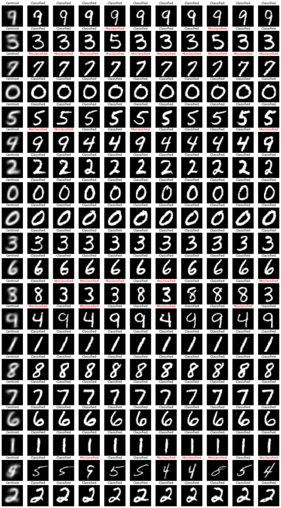

```python
# RUN CELL TO DISPLAY MISCLASSIFIED POINTS FOR RUN WITH LOWEST FINAL J_CLUST
display_misclassified(min_run_twenty, min_nearest_twenty, min_inferred_twenty, min_actual_twenty)
```

After plotting the group representatives for `min_run_twenty`, it seems like my hypothesis was indeed for correct for group 3. The actual labels of all of the ten nearest vectors were indeed *7*. Looking at the image of the representative for group 3, it is easy to see why I had mistaken for it to be a *9*. The signature enclosed, half-circle loop of the digit *9* seems faint, but it is distinct enough for it to be mistaken as *9*.

As mentioned above, this is because the vectors that are associated with the label *9* appear to be prevalent in the cluster, but nonexistent in the set of the ten nearest vectors. Since the group representative is the mean of all the vectors in the cluster, the fact that the group representative is muddled between *9* and *7*, indicates that when *9* and *7* are handwritten in such a way that they could be mistaken for each other, the data points associated with these digits are actually close together in the 784-vector space.

When *9* is handwritten in a distinct manner, where it is unlikely that it could be misrecognized, it gets clustered pretty well. For example, if you look at group 1 (the first row of images), you'll see that all of the ten nearest vectors were correctly classified as the digit *9*. This is because, when drawn as a complete enclosed circle with a straight line jutting downwards, it is unlikely that this could represent some other digit.

When the enclosed circle is drawn more lazily and wider, it seems that the clustering mistakes it for the digit *4*, which isn't unexpected, as this pattern was also observed in the Least Squares Classifier. This behavior is exemplified here in group 13, where the representative was inferred to be *9*, but its set of ten nearest vectors had a 60% classification rate as the the digit *4* was misclassified. Like *9* and *7* can be, *9* and *4* can sometimes share the same general proximity in the 784-vector space as well.

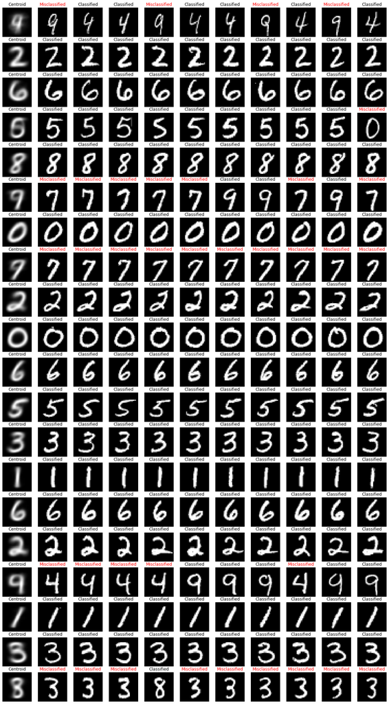

```python
# RUN CELL TO DISPLAY MISCLASSIFIED POINTS FOR RUN WITH HIGHEST FINAL J_CLUST
display_misclassified(max_run_twenty, max_nearest_twenty, max_inferred_twenty, max_actual_twenty)
```

Like the prior run, my hypothesis seems consistent for this set of images from `max_run_twenty` as well. Groups 6 and 8 were both inferred by me as to be the digit *9*, as eye-estimated from its group representatives. For the ten nearest vectors for group 6, only 3 of them were "correctly" classified to be the digit *9*. The rest were actually *7*. Likewise, all ten vectors in group 8 were deemed misclassified to be the digit *7*, because I had inferred its group representative to be the digit *9*. Similarly, I had inferred the representative from group 17 to be *9*, but it turns out half of the nearest vectors were *4*. I also thought that the representative of group 20 was *8*, but it turns out nine of the ten nearest vectors were actually *3*.

As reiterated above, these misclassifications are not a knock on the overall clustering itself, as most of the sets of the ten nearest vectors matched the inferred digit of its group representative. Rather, these misclassifications are due to the ambiguity in determining the digit of the group representatives by eye-estimation. For example, for group 20, I could have inferred its group representatives to be a *3*, and it would've been a different story as the classification rate of the nearest vectors would've been 90%.

I think the biggest observation to take away here is that the group representatives are not sometimes wholly representative of its cluster set. Because the representative vectors are the mean of its cluster, distinct digits when written similarly in curvature and shape can share the same cluster set as exemplified through groups 6 and 8, as well as 17 and 20. This in turn "muddles" or "blurs" the representative vector because it is the mean of vector of the datapoints in the group, leading to incorrect eye estimates. Within the scope of this project, it is impossible to say whether these specific cluster sets had for the most part accurately classified these groups. For that, we need to look beyond the ten nearest vectors and analyze the entire distribution set of the vectors in the clusters.

## K-means on 10 clusters

Here, we perform the `k-means` algorithm on the design matrix, *X*, using *k* = 10 clusters. We will repeat this experiment *P* = 20 times.

```python
# RUN THIS CELL TO PERFORM K-MEANS ON 10 CLUSTERS, 20 TIMES
min_run_ten, max_run_ten = repeat_kmeans(X, 10, 20)
```

```
Entering Run 1...
Percent decrease for loop 1 is nan%
Percent decrease for loop 2 is 6.66%
Percent decrease for loop 3 is 1.83%
Percent decrease for loop 4 is 1.15%
Percent decrease for loop 5 is 0.8%
Percent decrease for loop 6 is 0.53%
Percent decrease for loop 7 is 0.42%
Percent decrease for loop 8 is 0.31%
Percent decrease for loop 9 is 0.18%
Percent decrease for loop 10 is 0.08%
Percent decrease for loop 11 is 0.04%
Finished Run 1!
Entering Run 2...
Percent decrease for loop 1 is nan%
Percent decrease for loop 2 is 5.03%
Percent decrease for loop 3 is 1.79%
Percent decrease for loop 4 is 0.75%
Percent decrease for loop 5 is 0.29%
Percent decrease for loop 6 is 0.14%
Percent decrease for loop 7 is 0.08%
Percent decrease for loop 8 is 0.06%
Percent decrease for loop 9 is 0.06%
Percent decrease for loop 10 is 0.05%
Percent decrease for loop 11 is 0.05%
Percent decrease for loop 12 is 0.05%
Percent decrease for loop 13 is 0.06%
Percent decrease for loop 14 is 0.07%
Percent decrease for loop 15 is 0.08%
Percent decrease for loop 16 is 0.09%
Percent decrease for loop 17 is 0.08%
Percent decrease for loop 18 is 0.04%
Finished Run 2!
Entering Run 3...
Percent decrease for loop 1 is nan%
Percent decrease for loop 2 is 6.88%
Percent decrease for loop 3 is 1.85%
Percent decrease for loop 4 is 0.66%
Percent decrease for loop 5 is 0.32%
Percent decrease for loop 6 is 0.24%
```

[output cut: 222 more lines]

```
Entering Run 20...
Percent decrease for loop 1 is nan%
Percent decrease for loop 2 is 4.84%
Percent decrease for loop 3 is 1.32%
Percent decrease for loop 4 is 0.48%
Percent decrease for loop 5 is 0.3%
Percent decrease for loop 6 is 0.21%
Percent decrease for loop 7 is 0.15%
Percent decrease for loop 8 is 0.12%
Percent decrease for loop 9 is 0.1%
Percent decrease for loop 10 is 0.08%
Percent decrease for loop 11 is 0.06%
Percent decrease for loop 12 is 0.05%
Percent decrease for loop 13 is 0.04%
Finished Run 20!
```

The above call to **`repeat_kmeans`** returns the runs for **`k_means`** using 10 clusters which produced the lowest *J<sub>clust</sub>* value upon convergence and highest *J<sub>clust</sub>* upon convergence value. These runs are stored in `min_run_ten` and `max_run_ten`, respectively, and I will be referencing these variables as such for these next portions of the write-up.

### Visualization of *J<sub>clust</sub>*

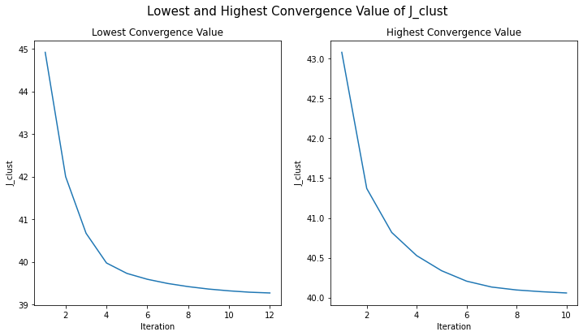

```python
# RUN THIS CELL TO VISUALIZE J_CLUST CONVERGENCE VALUES FOR BOTH RUNS
viz_jclust(min_run_ten, max_run_ten)
```

```python
# RUN THIS CELL TO PRINT THE MAXIMUM AND MINIMUM J_CLUST CONVERGENCE VALUES
print('The lowest convergence value of J_clust was {}'.format(round(min_run_ten[2][len(min_run_ten[2]) - 1], 2)))
print('The highest convergence value of J_clust was {}'.format(round(max_run_ten[2][len(max_run_ten[2]) - 1], 2)))
```

```
The lowest convergence value of J_clust was 39.27
The highest convergence value of J_clust was 40.06
```

As printed above, the lowest convergence value of *J<sub>clust</sub>* was around 39.27 and the highest convergence value of the objective was around 40.06. The line graphs are a little different for both runs. For `min_run_ten`, the concavity of the decline seemed more abrupt, compared to the *J<sub>clust</sub>* values of `max_run_ten`, which had a smoother decline.

Compared with the previous experiment, these clustering objective values are larger than the values obtained when we ran `k_means` 30 times using 20 clusters.

### Visualizing the Group Representatives as Images

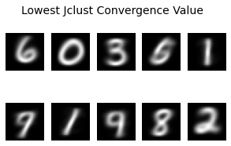

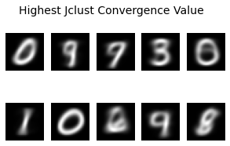

```python
# RUN THIS CELL TO DISPLAY THE K CENTROIDS AS IMAGES FOR BOTH RUNS
display_images(min_run_ten, max_run_ten)
```

Like the previous experiment, most of the digits are largely recognizable with a couple more exceptions this time around. *0* , *6* seem muddled together in one image for `max_run_ten`, where it is impossible to tell which one it is. *9* and *7*, and *9* and *4* seem especially ambiguous again for both runs. For the set of group representatives with the lowest final value of the clustering objective, I can see about two digits where the eye test may not be accurate, compared to the second set where about four digits seem harder to recognize.

To my surprise, since we are using 10 clusters, I expected each group representative to display each digit from *0 - 9*. Some digits are missing in both sets. Drawing from the observations from the previous experiment, this leads me to believe that the missing digits are part of the clusters where the centroid is hard to infer with a high degree of confidence, or as I call it, "muddled". For example, *7* isn't present in the group representatives of either run. But clusters whose representatives look like a cross between *9* and *7*, may contain the data points of *7* in unknown distributions in its clusters. Likewise, we can say the same for *4* and *9*.

### The 10 Nearest Images for Each Centroid

```python
# RUN THIS CELL TO GET THE 10 CLOSEST VECTORS, AND THEIR ACTUAL LABEL, TO EACH CENTROID
min_nearest_ten, min_actual_ten, max_nearest_ten, max_actual_ten = ten_nearest(min_run_ten, max_run_ten)
```

*6, 0, 3, 5, 1, 9, 1, 9, 8, 2*

*0, 9, 9, 3, 0, 1, 0, 6, 9, 8*

I inputted these values into two lists.

```python
# RUN THIS CELL TO STORE THE EYE ESTIMATES OF THE DIGITS INTO LISTS
min_inferred_ten = [6, 0, 3, 5, 1, 9, 1, 9, 8, 2]
max_inferred_ten = [0, 9, 9, 3, 0, 1, 0, 6, 9, 8]
```

#### Tables

The table below displays the number of correctly classified in the set of ten nearest vectors for `min_run_ten`.

```python
# RUN THIS CELL TO GENERATE TABLE FOR THE RUN WITH THE LOWEST FINAL J_CLUST VALUE
create_table(min_inferred_ten, min_actual_ten)
```

|  | Group Index | Inferred Digit | Correctly Classified |
| --- | --- | --- | --- |
| 0 | 1 | 6 | 10 |
| 1 | 2 | 0 | 10 |
| 2 | 3 | 3 | 9 |
| 3 | 4 | 5 | 3 |
| 4 | 5 | 1 | 10 |
| 5 | 6 | 9 | 1 |
| 6 | 7 | 1 | 10 |
| 7 | 8 | 9 | 8 |
| 8 | 9 | 8 | 10 |
| 9 | 10 | 2 | 10 |

Upon initial observation, it looks like for the most part `k_means` produced decent classifications for the ten nearest vectors for about eight of the ten clusters. The nearest vectors for groups 4 and 6, whose group represenatives I had inferred to be *5* and *9*, respectively had terrible results. Again, it looks like I had mistaken *7* for *9* in group 6, as the pattern of not being able to distinguish *9* and *7* was also recorded in the previous experiment and the Least Squares Classifiers.

However for group 4, this seems to be a first where I had inferred a group representative to be the digit *5* , but its nearest vectors had such a low classification rate. Only about three of the ten nearest vectors in that group seem to be correctly classified. My guess from looking at the group representative again, is that some of the nearest vectors for this group are either *6*'s or *0*'s.

The table below displays the number of correctly classified in the set of ten nearest vectors for `max_run_ten`.

```python
# RUN THIS CELL TO GENERATE TABLE FOR THE RUN WITH THE HIGHEST FINAL J_CLUST VALUE
create_table(max_inferred_ten, max_actual_ten)
```

|  | Group Index | Inferred Digit | Correctly Classified |
| --- | --- | --- | --- |
| 0 | 1 | 0 | 10 |
| 1 | 2 | 9 | 10 |
| 2 | 3 | 9 | 0 |
| 3 | 4 | 3 | 9 |
| 4 | 5 | 0 | 10 |
| 5 | 6 | 1 | 10 |
| 6 | 7 | 0 | 10 |
| 7 | 8 | 6 | 10 |
| 8 | 9 | 9 | 5 |
| 9 | 10 | 8 | 9 |

Like the previous run, this run which produced the *highest* final *J<sub>clust</sub>* value, also classified the digits with moderate accuracy. Of the ten groups, the ten nearest vectors to the group representatives of six clusters produced a 100% classification rate, identical to the run with the lowest final *J<sub>clust</sub>* value. Two more clusters had a classification rate of 90%.

The groups with misclassifications in the ten nearest vectors were groups 3 and 9, whose group representatives I had inferred to be *9* and *9*. This is no surprise based on the observations from the previous experiment. There are about three groups whose representatives I had inferred to be *9* in this run. One of these groups, group 2, had a 100% classification rate of its ten nearest vectors. This leads me to believe that group 2, had a distinct variation in handwriting of the digit *9*, where it is unlikely for it to be mistaken for *7* or *4*. So it is highly likely when we display the images in the next step, group 3 will probably be a set of *7*'s, and group 9, will be split between *9* and *4*'s.

#### Visualizing Misclassified Data Points as Images

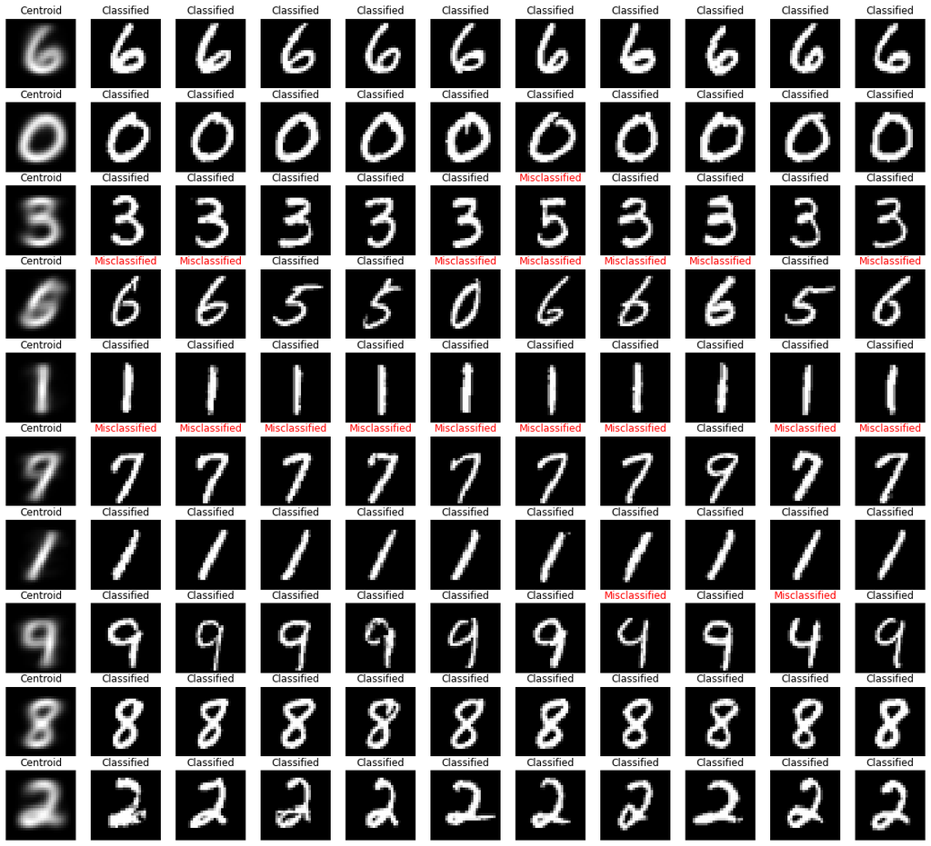

```python
# RUN CELL TO DISPLAY MISCLASSIFIED POINTS
display_misclassified(min_run_ten, min_nearest_ten, min_inferred_ten, min_actual_ten)
```

This observation is consistent with the pattern that I have seen so far, which is that *9* and *7*, and *9* and *4* are close together in the 784-vector space for certain handwritten variations of the digit. This can lead to them being clustered together, which then muddles, or blurs its group representative as a cross between the two digits.

A unique observation from the above images is that group 4 whose representative I had inferred to be *5*, had *6* *and* *0* in its set of nearest vectors. These digits don't necessarily have similar curvatures in the glyphs, but since we are using less clusters than the previous experiment, it would seem as if distinct digits can share the same proximity in the vector space.

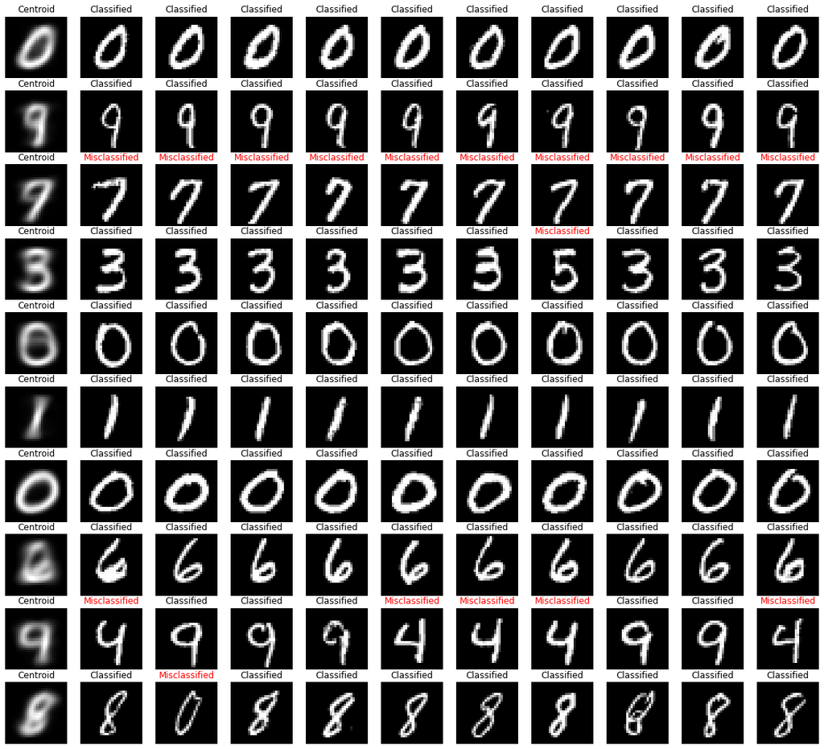

```python
# RUN CELL TO DISPLAY MISCLASSIFIED POINTS
display_misclassified(max_run_ten, max_nearest_ten, max_inferred_ten, max_actual_ten)
```

For this run, as mentioned above, I had inferred that three groups seemed to have *9* as the representative. I was right about for one these groups, group 2, as all ten of the nearest vectors matched my inference. Consistent with the pattern that I have seen above and for the Least Squares Classifier, *9* and *7*, and *9* and *4* are similar when handwritten in such a way, that they share the same proximity in the vector space. Thus this leads to the "misclassifications" as above.

## K-means on 5 clusters

Here, we perform the `k-means` algorithm on the design matrix, *X*, using *k* = 5 clusters. We will repeat this experiment *P* = 10 times.

```python
# RUN THIS CELL TO PERFORM K-MEANS ON 5 CLUSTERS, 10 TIMES
min_run_five, max_run_five = repeat_kmeans(X, 5, 10)
```

```
Entering Run 1...
Percent decrease for loop 1 is nan%
Percent decrease for loop 2 is 2.73%
Percent decrease for loop 3 is 1.19%
Percent decrease for loop 4 is 0.78%
Percent decrease for loop 5 is 0.37%
Percent decrease for loop 6 is 0.24%
Percent decrease for loop 7 is 0.21%
Percent decrease for loop 8 is 0.2%
Percent decrease for loop 9 is 0.18%
Percent decrease for loop 10 is 0.16%
Percent decrease for loop 11 is 0.14%
Percent decrease for loop 12 is 0.12%
Percent decrease for loop 13 is 0.09%
Percent decrease for loop 14 is 0.08%
Percent decrease for loop 15 is 0.07%
Percent decrease for loop 16 is 0.05%
Percent decrease for loop 17 is 0.04%
Finished Run 1!
Entering Run 2...
Percent decrease for loop 1 is nan%
Percent decrease for loop 2 is 2.65%
Percent decrease for loop 3 is 1.37%
Percent decrease for loop 4 is 1.61%
Percent decrease for loop 5 is 0.67%
Percent decrease for loop 6 is 0.23%
Percent decrease for loop 7 is 0.1%
Percent decrease for loop 8 is 0.06%
Percent decrease for loop 9 is 0.05%
Percent decrease for loop 10 is 0.05%
Finished Run 2!
Entering Run 3...
Percent decrease for loop 1 is nan%
Percent decrease for loop 2 is 3.66%
Percent decrease for loop 3 is 1.1%
Percent decrease for loop 4 is 0.69%
Percent decrease for loop 5 is 0.68%
Percent decrease for loop 6 is 0.56%
Percent decrease for loop 7 is 0.4%
Percent decrease for loop 8 is 0.29%
```

[output cut: 93 more lines]

```
Percent decrease for loop 3 is 2.07%
Percent decrease for loop 4 is 1.19%
Percent decrease for loop 5 is 0.85%
Percent decrease for loop 6 is 0.62%
Percent decrease for loop 7 is 0.39%
Percent decrease for loop 8 is 0.25%
Percent decrease for loop 9 is 0.18%
Percent decrease for loop 10 is 0.14%
Percent decrease for loop 11 is 0.11%
Percent decrease for loop 12 is 0.09%
Percent decrease for loop 13 is 0.08%
Percent decrease for loop 14 is 0.06%
Percent decrease for loop 15 is 0.05%
Percent decrease for loop 16 is 0.04%
Finished Run 10!
```

The above call to **`repeat_kmeans`** returns the runs for **`k_means`** using 5 clusters which produced the lowest *J<sub>clust</sub>* value upon convergence and highest *J<sub>clust</sub>* upon convergence value. These runs are stored in `min_run_five` and `max_run_five`, respectively, and I will be referencing these variables for these next portions of the write-up.

### Visualization of *J<sub>clust</sub>*

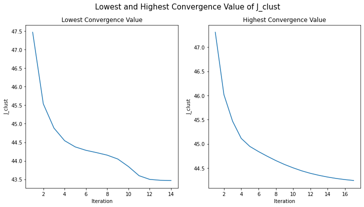

```python
# RUN THIS CELL TO VISUALIZE J_CLUST CONVERGENCE VALUES FOR BOTH RUNS
viz_jclust(min_run_five, max_run_five)
```

```python
# RUN THIS CELL TO PRINT THE MAXIMUM AND MINIMUM J_CLUST CONVERGENCE VALUES
print('The lowest convergence value of J_clust was {}'.format(round(min_run_five[2][len(min_run_five[2]) - 1], 2)))
print('The highest convergence value of J_clust was {}'.format(round(max_run_five[2][len(max_run_five[2]) - 1], 2)))
```

```
The lowest convergence value of J_clust was 43.47
The highest convergence value of J_clust was 44.24
```

The above line graphs depict *J<sub>clust</sub>* vs iteration number for two of the initial 5 random assignment of group representatives that gave the lowest and highest final values of *J<sub>clust</sub>* upon convergence. As printed above, the lowest convergence value of the objective was around 43.47 and the highest convergence value of the objective was around 44.24. The line graph for `min_run_five`, has a little bump before the soft decline. This behavior wasn't noticed in any of the graphs plotted so far, leading me to believe that running **`k_means`** with less clusters than the total amount classes would result in more erratic clusterings.

Compared with the previous experiments, these clustering objectives are much larger than when running `k_means` 20 times using 10 clusters or 30 times with 20 clusters. The pattern here seems to be that a lower amount of clusters and a lower amount of `k_means` runs will assuredly output a higher clustering objective upon convergence. This makes sense when we are working with 10 classes and 5 clusters, because the centroids of the clusters are influenced by data points that are further apart.

### Visualizing the Group Representatives as Images

```python
# RUN THIS CELL TO DISPLAY THE K CENTROIDS AS IMAGES FOR BOTH RUNS
display_images(min_run_five, max_run_five)
```

[output not shown]

### The 10 Nearest Images for Each Centroid

```python
# RUN THIS CELL TO GET THE 10 CLOSEST VECTORS, AND THEIR ACTUAL LABEL, TO EACH CENTROID
min_nearest_five, min_actual_five, max_nearest_five, max_actual_five = ten_nearest(min_run_five, max_run_five)
```

Going back to our above images of the group representatives. We can manually (by eye estimation) deduce the digit that each group is supposed to represent. For `min_run_five`, the digits in order seem to be:

*0, 3, 9, 1, 6*

Likewise, for `max_run_five`, the digits in order look like:

*8, 0, 1, 9, 9*

I inputted these values into two lists.

```python
# RUN THIS CELL TO STORE THE EYE ESTIMATES OF THE DIGITS INTO LISTS
min_inferred_five = [0, 3, 9, 1, 6]
max_inferred_five = [8, 0, 1, 9, 9]
```

#### Tables

The table below displays the number of correctly classified in the set of ten nearest vectors for `min_run_five`.

```python
# RUN THIS CELL TO GENERATE TABLE FOR THE RUN WITH THE LOWEST FINAL J_CLUST VALUE
create_table(min_inferred_five, min_actual_five)
```

|  | Group Index | Inferred Digit | Correctly Classified |
| --- | --- | --- | --- |
| 0 | 1 | 0 | 10 |
| 1 | 2 | 3 | 9 |
| 2 | 3 | 9 | 10 |
| 3 | 4 | 1 | 10 |
| 4 | 5 | 6 | 10 |

For this run, it looks like **`k-means`** was surprisingly accurate in classifying the ten nearest vectors of the 5 clusters. Of the 10 nearest vectors for each of the 5 group representatives, only one data point was misclassified, and that was the group where the inferred representative was *3*.

```python
# RUN THIS CELL TO GENERATE TABLE FOR THE RUN WITH THE HIGHEST FINAL J_CLUST VALUE
create_table(max_inferred_five, max_actual_five)
```

|  | Group Index | Inferred Digit | Correctly Classified |
| --- | --- | --- | --- |
| 0 | 1 | 8 | 7 |
| 1 | 2 | 0 | 10 |
| 2 | 3 | 1 | 10 |
| 3 | 4 | 9 | 8 |
| 4 | 5 | 9 | 3 |

Compared to `min_run_five`, this run fared a little worse in the classifications of the ten nearest vectors. Groups 4 and 5, whose representatives I had inferred to be *9*, had an 80% and 30% classification rate, respectively, in their sets of ten nearest vectors. It is hard to tell what digit the representative from group 4 is, since it is very muddled, but I am surprised of the high classification rate in its set of nearest vectors. And of course, for group 5, I had yet again inferred that its representative was *9*, when *7* would've most likely been a better match.

#### Visualizing Misclassified Data Points as Images

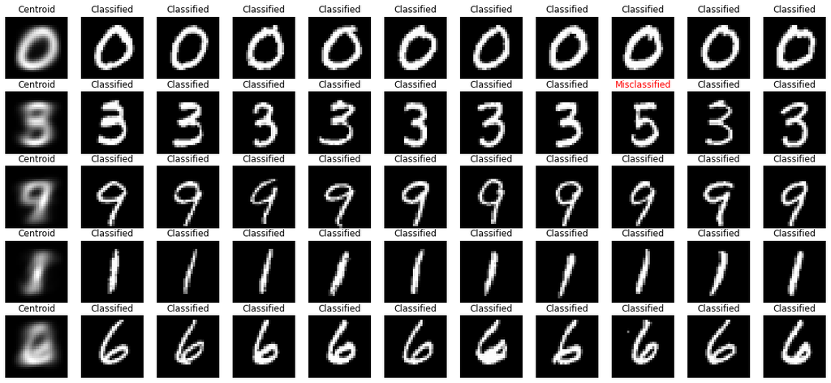

```python
# RUN CELL TO DISPLAY MISCLASSIFIED POINTS
display_misclassified(min_run_five, min_nearest_five, min_inferred_five, min_actual_five)
```

Surprisingly, when using five clusters, **`k_means`** worked surprisingly well in accurately classifying the ten nearest vectors of the group representatives. I doubt however, the overall clustering is successful as the displayed images of the group representatives are blurry and muddled (with the exception of the digit *0*), indicating that there are multiple classes of digits are present in the clusters.

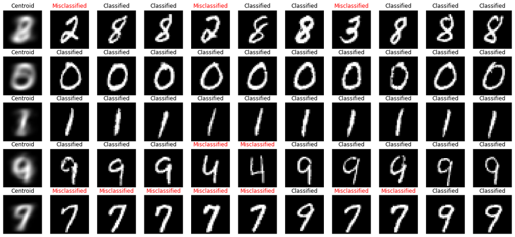

```python
# RUN CELL TO DISPLAY MISCLASSIFIED POINTS
display_misclassified(max_run_five, max_nearest_five, max_inferred_five, max_actual_five)
```

It seems to be a tale as old as time. For all three experiments and the Least Squares Classifier, the pattern of not being able to distinguish between *9* and *7*, and *9* and *4* is consistent throughout. Granted for this run, I could have interpreted the representative for Group 5 as *7*, but this just works to solidy the theory that there are certain variations of handwritten *9*'s that are extremely close to *7* in the 784-vector space.

## Comparisons in Performance between Least Squares Classifier and K-Means Clustering

**`k_means`** is an *unsupervised* machine learning algorithm, meaning it makes inferences on the dataset without referring to pre-existing labels. In this part of the project, **`k_means`** partitioned the 60,000 784-vectors into *k* clusters, in which each datapoint in the 784-vector space belongs to the cluster with the closest group representative (centroid). The Least Squares Classifiers on the other hand, are examples of *supervised* algorithms in which they essentially fitted a sophisticated decision boundary using *labeled* training data of the 60,000 784-vectors.

Despite the inherent differences, both classifiers seemed to have certain commonalities. Both had trouble in distinguishing handwritten digits that are similar in curvature and shape, and thus closer in proximity in the 784-vector space. For example, an exceptionally common trend between both classifiers is that the digit pairs *9*,*7*, *9*,*4*, *3*,*8*, and *3*,*5* are commonly misclassified with each other.

From the Linear Squares Classifiers, the One vs One Classifer worked best because it differentiates between every pair *i*, *j* in *K* classes, producing an error rate around 7%. For K-means clustering, using a larger number of clusters, such as 20, and running more trials produced a lower clustering objective value, which depicts the strength of the total clustering. Additionaly, the first experiment also produced relatively clearer images of the group representatives, indicating that digits that are closer together in the 784-vector space have been more successfuly clustered as they weren't "clouded" or "muddles" by misclassified data points.